# M07 Exercises

DS 5100 | Spring 2022

# Exercise 7.1

Create your own class with the following:

- a docstring
- a static attribute
- an `__init__` function that takes one required argument and sets an instance attribute to that value
- a method that operates on the two attributes and prints the result

```python
class MyClass():
    """This a class I've written for a class I am taking :-)"""

    att1 = "foo"

    def __init__(self, att2):
        self.att2 = att2

    def add(self):
        self.msg = self.att1 + ' ' + self.att2
        print(self.msg)
```

# Exercise 7.2

Now that you've defined your class, create an object by passing the argument required by `__init__`.

Use `object.attribute` to show the two attributes.

Then call the method.

```python
obj_1 = MyClass("This is not a pipe")
```

```python
obj_1.att1, obj_1.att2
```

```
('foo', 'This is not a pipe')
```

```python
obj_1.add()
```

```
foo This is not a pipe
```

# Exercise 7.3

Create a class called `Student` that contains a student's grades for a given class.

- It should store the grades as a Pandas **Series** of type `float`, with the index being the assignment name.
- It should have an initialization method that takes the student's full name and user ID.
- It should have a method to add an assignment with its grade to the Series object.
  - Hint: to add a new observation (row) to a Series, you can do this: `foo.loc['new_key'] = new_value`
- It should also have a method to plot the student's grades as a bar chart.
  - The plot should have a title stating the student's name, and ID in parentheses.

```python
import pandas as pd

class Student:

    def __init__(self, name, id):
        self.name = name
        self.id = id
        self.grades = pd.Series(dtype=float)

    def add_grade(self, assignment, grade):
        self.grades.loc[assignment] = grade

    def show_grades(self):
        self.grades.plot.bar(title=f"Grades for {self.name} ({self.id})")
```

# Exercise 7.3a

Create three instances, each with four grades.

- Use HW01, HW02, HW03, and HW04 as assignment names.
- Call the plot method for each.

```python
student1 = Student("Quetzil Castaneda", 'qc4x')
```

```python
student1.add_grade("HW01", 100)
student1.add_grade("HW02", 95)
student1.add_grade("HW03", 91)
student1.add_grade("HW04", 98)
```

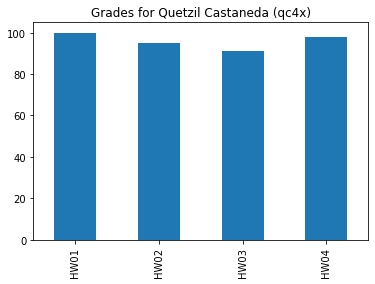

```python
student1.show_grades()
```

# Exercise 7.4

The fictitious global e-commerce and cloud computing juggernaut UVAWS offers cloud computing as a service with a range of server options. You will define and use with a class that instantiates a cloud server. Define a class with these requirements:

- Name: `V3`
- Attributes:
  - `instance_size` a string representing one of `small`, `medium` , and `large`
  - `num_vcpus` an integer representing the number of virtual CPUs.
  - `memory` an integer representing the number of GBs.
  - `disk_space` a float representing the number of TBs.
- Methods (with parameters):
  - `add_disk_space(amt_to_add)`. This adds disk space to the current disk space.
    - `amt_to_add` will be a float.
  - `has_enough_disk_space(amt_required)` this checks if the amount required is available.
    - `amt_required` will be a float.
    - Use natural language to print an appropriate response while also returning a boolean value.
  - `__init__()` That sets all of the attributes above.

```python
class V3():

    def __init__(self, instance_size, num_vcpus, memory, disk_space):
        self.instance_size = instance_size
        self.num_vcpus = num_vcpus
        self.memory = memory
        self.disk_space = disk_space

    def add_disk_space(self, amt_to_add):
        self.disk_space += amt_to_add

    def has_enough_disk_space(self, amt_required):
        if self.disk_space >= amt_required:
            print("You have enough disk space!")
            return True
        else:
            print("You don't have enough disk space!")
            return False
```

# Exercise 7.5

Instantiate a V3 object with these attribute values:

```
instance_size: 'large'
num_vcpus:     32
memory:        256
disk_space:    1.
```

Then:

1. Add $2.0$ TB disk space to the instance.
2. Display the updated disk space using dot operator to display the attribute.
3. See if the instance has enough disk space, using a request of $10.0$ TB.

```python
my_v3 = V3('large', 32, 256, 1.)
my_v3.add_disk_space(2.)
```

```python
my_v3.disk_space
```

```
3.0
```

```python
my_v3.has_enough_disk_space(10.)
```

```
You don't have enough disk space!
```

```
False
```

# Exercise 7.6

Write a Python class named Circle constructed by a radius\ and two methods which will compute the area and the perimeter of the circle.

```python
class Circle():

    PI = 3.14

    def __init__(self, r):
        self.radius = r

    def area(self):
        return self.radius**2 * self.PI

    def perimeter(self):
        return 2 * self.radius * self.PI
```

```python
my_circle = Circle(8)
```

```python
my_circle.area()
```

```
200.96
```

```python
my_circle.perimeter()
```

```
50.24
```

# Exercise 7.7

Write a Python class named Rectangle constructed by a length and width and a method which will compute the area of a rectangle.

```python
class Rectangle():

    def __init__(self, l, w):
        self.length = l
        self.width  = w

    def rectangle_area(self):
        return self.length * self.width
```

```python
newRectangle = Rectangle(12, 10)
```

```python
newRectangle.rectangle_area()
```

```
120
```

# Exercisse 7.8

Write a class `Geometry` with a static method to compute the area of a rectangle.

Call the method with length as $10$ and width as $15$.

```python
class Geometry():

    def get_rectangle_area(l, w):
        return l * w
```

```python
Geometry.get_rectangle_area(10, 15)
```

```
150
```